# Lab 6

```python
import pandas as pd
df = pd.read_csv("https://www.dropbox.com/s/aohbr6yb9ifmc8w/heart_attack.csv?dl=1")
hav = pd.read_csv("https://www.dropbox.com/s/jkwqdiyx6o6oad0/heart_attack_validation.csv?dl=1")
```

```python
from sklearn.preprocessing import StandardScaler
from sklearn.neighbors import KNeighborsClassifier
from sklearn.pipeline import Pipeline
from sklearn.compose import ColumnTransformer
import pandas as pd
import numpy as np
from sklearn.metrics import accuracy_score
from sklearn.model_selection import train_test_split, GridSearchCV
from sklearn.linear_model import LogisticRegression
from sklearn.tree import DecisionTreeClassifier
from sklearn.metrics import roc_curve, precision_recall_curve, auc
from plotnine import ggplot, aes, geom_line, geom_abline, labs
from sklearn.metrics import confusion_matrix, roc_auc_score, precision_score, recall_score
from sklearn.metrics import cohen_kappa_score
from sklearn.inspection import permutation_importance
```

```python
df.head()
```

|  | age | sex | cp | trtbps | chol | restecg | thalach | output |
| --- | --- | --- | --- | --- | --- | --- | --- | --- |
| 0 | 63 | 1 | 3 | 145 | 233 | 0 | 150 | 1 |
| 1 | 37 | 1 | 2 | 130 | 250 | 1 | 187 | 1 |
| 2 | 56 | 1 | 1 | 120 | 236 | 1 | 178 | 1 |
| 3 | 57 | 0 | 0 | 120 | 354 | 1 | 163 | 1 |
| 4 | 57 | 1 | 0 | 140 | 192 | 1 | 148 | 1 |

```python
X = df.drop(["output"], axis = 1)
y = df["output"]
```

```python
mask = ~pd.isna(y)
X_clean = X[mask]
y_clean = y[mask]

X = X_clean
y = y_clean
```

```python
numeric = X.select_dtypes(include={np.number}).columns
```

```python
X_train, X_test, y_train, y_test = train_test_split(X, y, test_size=0.3, random_state=42)
```

#Parts 1, 2, 4 & 5

#KNN Model

```python
ct = ColumnTransformer(
  [
    ("Standardize", StandardScaler(), numeric)
  ],
  remainder = "passthrough"
)

pipeline = Pipeline([
    ('scaler', StandardScaler()),
    ('model', KNeighborsClassifier())
])

pipeline.fit(X_train, y_train)
```

```
Pipeline(steps=[('scaler', StandardScaler()),
                ('model', KNeighborsClassifier())])
```

Confusion Matrix

```python
y_train_ = pd.Series(pipeline.predict(X_train), name = "Predicted")

pd.crosstab(y_train, y_train_, margins=True)
```

| Predicted output | 0 | 1 | All |
| --- | --- | --- | --- |
| 0 | 16 | 16 | 32 |
| 1 | 48 | 52 | 100 |
| All | 64 | 68 | 132 |

```python
accuracy_score(y_train, y_train_)
```

```
0.837696335078534
```

```python
param = {'model__n_neighbors': [0.01, 0.1, 1, 10, 100],}
```

```python
grid_search = GridSearchCV(pipeline, param, cv=5, scoring='roc_auc')
```

```python
grid_search.fit(X_train, y_train)
```

```python
best_model = grid_search.best_params_
```

```python
best_model
```

```
{'model__n_neighbors': 100}
```

Cross Validated ROC AUC Score for the KNN Model

```python
grid_search.best_score_
```

```
np.float64(0.8752192982456141)
```

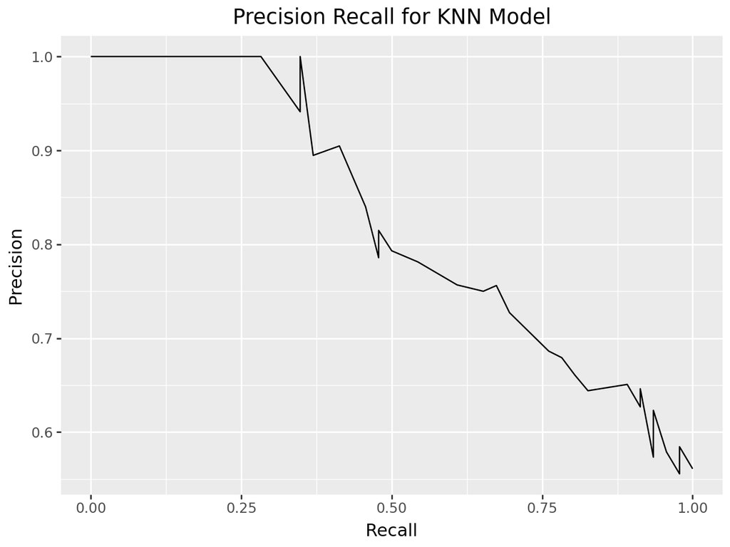

```python
best_estimator = grid_search.best_estimator_
y_pred_proba = best_estimator.predict_proba(X_test)[:, 1]


precisions, recalls, thresholds = precision_recall_curve(
    y_test,
    y_pred_proba
)
auprc_score = auc(recalls, precisions)

df_pr = pd.DataFrame({
    'Recall': recalls,
    'Precision': precisions
})

plot = (
    ggplot(df_pr, aes(x='Recall', y='Precision'))
    + geom_line()
    + labs(
        title=f'Precision Recall for KNN Model',
        x='Recall',
        y='Precision'))

plot
```

Cross Validated KNN Metrics

```python
#I looked up the function .ravel() to help with this section
y_test_pred = best_estimator.predict(X_test)

cm = confusion_matrix(y_test, y_test_pred)

TN, FP, FN, TP = cm.ravel()

tpr = TP / (TP + FN)

precision = TP / (TP + FP)

predicted_negatives = TN + FN
npv = TN / predicted_negatives

TotalOb = TP + TN + FP + FN
accuracy = (TP +TN) / TotalOb

print("True Positive " + str(TP))
print("False Negitive " + str(FN))
print("True positive / Recall " + str(tpr))
print("Precision " + str(precision))
print("True negative rate " + str(npv))
print("Accuracy " + str(accuracy))
```

```
True Positive 25
False Negitive 21
True positive / Recall 0.5434782608695652
Precision 0.78125
True negative rate 0.58
Accuracy 0.6585365853658537
```

Validation data metrics

```python
X_val = hav.drop(columns=['output'])
y_val = hav['output']


y_val_prob = best_estimator.predict_proba(X_val)[:, 1]

y_val_pred = best_estimator.predict(X_val)

cm_val = confusion_matrix(y_val, y_val_pred)

roc_auc_val = roc_auc_score(y_val, y_val_prob)

precision_val = precision_score(y_val, y_val_pred)

recall_val = recall_score(y_val, y_val_pred)

print(cm_val)

print("ROC AUC " + str(roc_auc_val))
print("Precision " + str(precision_val))
print("Recall " + str(recall_val))
```

```
[[11  0]
 [ 5 14]]
ROC AUC 0.9090909090909091
Precision 1.0
Recall 0.7368421052631579
```

Top 3 most important variables for KNN Model

```python
result = permutation_importance(pipeline, X_test, y_test, n_repeats=10, random_state=42)

importance_df = pd.DataFrame({
    'Feature': X.columns,
    'Importance': result.importances_mean
}).sort_values(by='Importance', ascending=False)

top3 = importance_df.head(3)
print(top3)
```

```
   Feature  Importance
1      sex    0.024390
2       cp    0.018293
6  thalach    0.015854
```

Cohens Kappa

```python
kappa_score = cohen_kappa_score(y_test, y_test_pred)

print("Cohen's Kappa Score " + str(kappa_score))
```

```
Cohen's Kappa Score 0.33487833140208567
```

#Logistic Regression Model

```python
X_train, X_test, y_train, y_test = train_test_split(X, y, test_size=0.3, random_state=42)
```

```python
ct = ColumnTransformer(
  [
    ("Standardize", StandardScaler(), numeric)
  ],
  remainder = "passthrough"
)

pipeline = Pipeline([
    ('scaler', StandardScaler()),
    ('model', LogisticRegression(random_state=42))
])
```

```python
pipeline.fit(X_train, y_train)
```

```
Pipeline(steps=[('scaler', StandardScaler()),
                ('model', LogisticRegression(random_state=42))])
```

```python
y_train_ = pd.Series(pipeline.predict(X_train), name = "Predicted")
```

Confusion Matrix

```python
crosstab = pd.crosstab(y_train, y_train_, margins=True)
crosstab
```

| Predicted output | 0 | 1 | All |
| --- | --- | --- | --- |
| 0 | 15 | 17 | 32 |
| 1 | 46 | 54 | 100 |
| All | 61 | 71 | 132 |

```python
accuracy = accuracy_score(y_train, y_train_)
accuracy
```

```
0.8481675392670157
```

```python
param = {'model__C': [0.01, 0.1, 1, 10, 100]}
```

```python
grid_search = GridSearchCV(
    pipeline,
    param,
    cv=5,
    scoring='roc_auc'
)
```

```python
grid_search.fit(X_train, y_train)
```

```
GridSearchCV(cv=5,
             estimator=Pipeline(steps=[('scaler', StandardScaler()),
                                       ('model',
                                        LogisticRegression(random_state=42))]),
             param_grid={'model__C': [0.01, 0.1, 1, 10, 100]},
             scoring='roc_auc')
```

```python
best_model = grid_search.best_params_
best_model
```

```
{'model__C': 0.1}
```

Cross Validated ROC AUC score for logistic regression

```python
grid_search.best_score_
```

```
np.float64(0.8955263157894737)
```

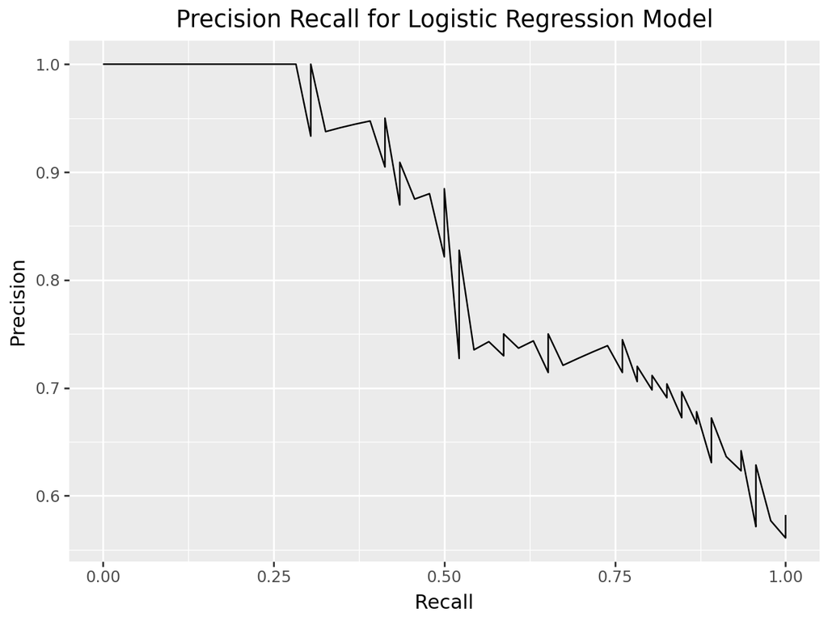

```python
best_estimator = grid_search.best_estimator_
y_pred_proba = best_estimator.predict_proba(X_test)[:, 1]


precisions, recalls, thresholds = precision_recall_curve(
    y_test,
    y_pred_proba
)
auprc_score = auc(recalls, precisions)

df_pr = pd.DataFrame({
    'Recall': recalls,
    'Precision': precisions
})

plot = (
    ggplot(df_pr, aes(x='Recall', y='Precision'))
    + geom_line()
    + labs(
        title=f'Precision Recall for Logistic Regression Model',
        x='Recall',
        y='Precision'
    ))

plot
```

Cross Validated Logistic regression Metrics

```python
y_test_pred = best_estimator.predict(X_test)

cm = confusion_matrix(y_test, y_test_pred)

TN, FP, FN, TP = cm.ravel()

tpr = TP / (TP + FN)

precision = TP / (TP + FP)

predicted_negatives = TN + FN
npv = TN / predicted_negatives

TotalOb = TP + TN + FP + FN
accuracy = (TP +TN) / TotalOb

print("True Positive " + str(TP))
print("False Negitive " + str(FN))
print("True positive / Recall " + str(tpr))
print("Precision " + str(precision))
print("True negative rate " + str(npv))
print("Accuracy " + str(accuracy))
```

```
True Positive 29
False Negitive 17
True positive / Recall 0.6304347826086957
Precision 0.7435897435897436
True negative rate 0.6046511627906976
Accuracy 0.6707317073170732
```

Validation Data Metrics

```python
X_val = hav.drop(columns=['output'])
y_val = hav['output']


y_val_prob = best_estimator.predict_proba(X_val)[:, 1]

y_val_pred = best_estimator.predict(X_val)

cm_val = confusion_matrix(y_val, y_val_pred)

roc_auc_val = roc_auc_score(y_val, y_val_prob)

precision_val = precision_score(y_val, y_val_pred)

recall_val = recall_score(y_val, y_val_pred)

print(cm_val)

print("ROC AUC " + str(roc_auc_val))
print("Precision " + str(precision_val))
print("Recall " + str(recall_val))
```

```
[[ 9  2]
 [ 5 14]]
ROC AUC 0.8995215311004785
Precision 0.875
Recall 0.7368421052631579
```

```python
features = X.columns.tolist()
bestmodel = pipeline.named_steps['model']
coefs = bestmodel.coef_[0]
importance_df = pd.DataFrame({
    'Feature': features,
    'Coefficient': coefs,
    'Absolute Importance': abs(coefs)
}).sort_values(by='Absolute Importance', ascending=False)

top3 = importance_df.head(3)[['Feature', 'Coefficient']]
print(top3.to_string(index=False))
```

```
Feature  Coefficient
thalach     1.328460
    sex    -1.154855
     cp     0.881945
```

Cohens Kappa

```python
kappa_score = cohen_kappa_score(y_test, y_test_pred)

print("Cohen's Kappa Score " + str(kappa_score))
```

```
Cohen's Kappa Score 0.34535777646363097
```

#Decision Tree

```python
X_train, X_test, y_train, y_test = train_test_split(X, y, test_size=0.3, random_state=42)
```

```python
ct = ColumnTransformer(
  [
    ("Standardize", StandardScaler(), numeric)
  ],
  remainder = "passthrough"
)

pipeline = Pipeline([
    ('scaler', StandardScaler()),
    ('model', DecisionTreeClassifier(random_state=42))
])
```

```python
pipeline.fit(X_train, y_train)
```

```
Pipeline(steps=[('scaler', StandardScaler()),
                ('model', DecisionTreeClassifier(random_state=42))])
```

```python
y_train_ = pd.Series(pipeline.predict(X_train), name = "Predicted")
```

```python
crosstab1 = pd.crosstab(y_train, y_train_, margins=True)
crosstab1
```

| Predicted output | 0 | 1 | All |
| --- | --- | --- | --- |
| 0 | 20 | 12 | 32 |
| 1 | 45 | 55 | 100 |
| All | 65 | 67 | 132 |

```python
accuracy1 = accuracy_score(y_train, y_train_)
accuracy1
```

```
1.0
```

```python
param = {'model__max_depth': [3, 5, 7, 9, 11]}
```

```python
grid_search = GridSearchCV(pipeline, param, cv=5, scoring='roc_auc')
```

```python
grid_search.fit(X_train, y_train)
```

```
GridSearchCV(cv=5,
             estimator=Pipeline(steps=[('scaler', StandardScaler()),
                                       ('model',
                                        DecisionTreeClassifier(random_state=42))]),
             param_grid={'model__max_depth': [3, 5, 7, 9, 11]},
             scoring='roc_auc')
```

```python
best_model = grid_search.best_params_
best_model
```

```
{'model__max_depth': 3}
```

Cross Validated ROC AUC score for decision tree

```python
grid_search.best_score_
```

```
np.float64(0.7853654970760233)
```

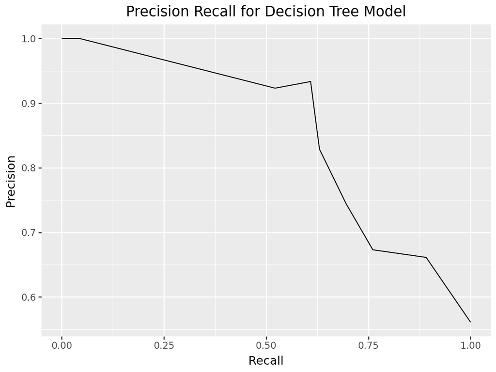

```python
best_estimator = grid_search.best_estimator_
y_pred_proba = best_estimator.predict_proba(X_test)[:, 1]


precisions, recalls, thresholds = precision_recall_curve(
    y_test,
    y_pred_proba
)
auprc_score = auc(recalls, precisions)

df_pr = pd.DataFrame({
    'Recall': recalls,
    'Precision': precisions
})

plot = (
    ggplot(df_pr, aes(x='Recall', y='Precision'))
    + geom_line()
    + labs(
        title=f'Precision Recall for Decision Tree Model',
        x='Recall',
        y='Precision'
    ))

plot
```

```python
auprc_score
```

```
np.float64(0.8541612235313266)
```

Cross Validated Decision tree Metrics

```python
y_test_pred = best_estimator.predict(X_test)

cm = confusion_matrix(y_test, y_test_pred)

TN, FP, FN, TP = cm.ravel()

tpr = TP / (TP + FN)

precision = TP / (TP + FP)

predicted_negatives = TN + FN
npv = TN / predicted_negatives

TotalOb = TP + TN + FP + FN
accuracy = (TP +TN) / TotalOb

print("True Positive " + str(TP))
print("False Negitive " + str(FN))
print("True positive / Recall " + str(tpr))
print("Precision " + str(precision))
print("True negative rate " + str(npv))
print("Accuracy " + str(accuracy))
```

```
True Positive 32
False Negitive 14
True positive / Recall 0.6956521739130435
Precision 0.7441860465116279
True negative rate 0.6410256410256411
Accuracy 0.6951219512195121
```

Validation data metrics

```python
X_val = hav.drop(columns=['output'])
y_val = hav['output']


y_val_prob = best_estimator.predict_proba(X_val)[:, 1]

y_val_pred = best_estimator.predict(X_val)

cm_val = confusion_matrix(y_val, y_val_pred)

roc_auc_val = roc_auc_score(y_val, y_val_prob)

precision_val = precision_score(y_val, y_val_pred)

recall_val = recall_score(y_val, y_val_pred)

print(cm_val)

print("ROC AUC " + str(roc_auc_val))
print("Precision " + str(precision_val))
print("Recall " + str(recall_val))
```

```
[[ 8  3]
 [ 6 13]]
ROC AUC 0.7775119617224878
Precision 0.8125
Recall 0.6842105263157895
```

```python
coef = X.columns.tolist()

bestmodel = grid_search.best_estimator_.named_steps['model']

importances = bestmodel.feature_importances_

importance_df = pd.DataFrame({
    'Feature': coef,
    'Importance': importances
}).sort_values(by='Importance', ascending=False)

top3 = importance_df.head(3)[['Feature', 'Importance']]
print(top3.to_string(index=False))
```

```
Feature  Importance
thalach    0.554142
     cp    0.229509
    sex    0.102704
```

Cohens Kappa

```python
kappa_score = cohen_kappa_score(y_test, y_test_pred)

print("Cohen's Kappa Score " + str(kappa_score))
```

```
Cohen's Kappa Score 0.3865948533812089
```

```python
coef = X.columns.tolist()

bestmodel = grid_search.best_estimator_.named_steps['model']

importances = bestmodel.feature_importances_

importance_df = pd.DataFrame({
    'Feature': coef,
    'Importance': importances
}).sort_values(by='Importance', ascending=False)

top3 = importance_df.head(3)[['Feature', 'Importance']]
print(top3.to_string(index=False))
```

```
Feature  Importance
thalach    0.554142
     cp    0.229509
    sex    0.102704
```

The top 3 predictors for predicting heart attach at thalach, sex and cp

#Part 3

Q1

- I would use the true positive rate because getting this wrong has a lot of consequences.Maximizing the true positive rate means there are less false negatives.
- I would recommend the decision tree model because it had the highest true positive rate and this is a mission critical task
- I would expect the score from my chosen metric to be close to its cross validated score. Hopefully it would predict as accurately on unforseen data as it does on the training and test data.

Q2

- I would choose the precision metric for this model becuase we want to minimize false positives. Or in other words, only admit patients that actually need treatment
- For this situation I would choose the KNN model because it has the highest precision score.
- I would expect the score from my chosen metric to be close to its cross validated score. Hopefully it would predict as accurately on unforseen data as it does on the training and test data

Q4

- We would use the accuracy score because it gives an overall correctness for the models predictions and therefore can gauge if the doctors are accurate
- I would reccomend the decision tree model because it has the highest accuracy score and therefore would be able to more accurately gauge if the doctors have a correct diagnosis
- I would expect the score from my chosen metric to be close to its cross validated score. Hopefully it would predict as accurately on unforseen data as it does on the training and test data

#Part 5

Cohens Kappa interpretation

From my understanding, Cohens Kappa has a more in depth process of calculating accuracy and takes chance out of it. When you are calculating accuracy its possible for the dataset to be heavily skewed one way and if you predict that way you are likely always to be right. Cohens Kappa takes the chance out of it no matter how the data is skewed and only gives credit to correct predictions.